# final homework

Ruizhe Xu

2020/7/18

# 体检数据分析

## 数据的基本处理

首先将体检数据导入进R，体检数据依次包含：性别、年龄、体重、身高、是否吸烟、是否喝酒、葡萄糖、收缩压、舒张压、甘油三脂、高密度脂蛋白胆固醇与是否患代谢综合症。

```r
phy_test=read_csv("data/phy_test.csv")
head(phy_test)
```

```
## # A tibble: 6 x 12
##   gender   age weight height smoke drunk   FPG   sbp   dbp    TG HDL_C
##   <chr>  <dbl>  <dbl>  <dbl> <chr> <chr> <dbl> <dbl> <dbl> <dbl> <dbl>
## 1 Male      56   66.3   171  Yes   Yes    5.01    95    60  0.74  1.79
## 2 Female    27   54.5   172  No    No     4.44   112    58  0.75  2.17
## 3 Male      64   59.9   159  No    Yes    5.93   141    81  1.76  1.91
## 4 Male      43   59.5   168. No    No     5.68   100    69  5.03  1.2
## 5 Female    59   47.8   160. No    No     6.45   107    57  0.84  1.53
## 6 Male      64   72.1   176. No    No     5.34   137    80  0.83  1.81
## # ... with 1 more variable: whether_sick <chr>
```

将数据中的Yes与No的选项换成TRUE与FALSE的逻辑值，同时计算BMI值=体重(Kg)/(身高(m)*身高(m))

```r
phy_test$smoke[which(phy_test$smoke=="Yes")]=TRUE
phy_test$smoke[which(phy_test$smoke=="No")]=FALSE
phy_test$drunk[which(phy_test$drunk=="Yes")]=TRUE
phy_test$drunk[which(phy_test$drunk=="No")]=FALSE
phy_test$whether_sick[which(phy_test$whether_sick=="Yes")]=TRUE
phy_test$whether_sick[which(phy_test$whether_sick=="No")]=FALSE
phy_test$whether_sick=as.logical(phy_test$whether_sick)
phy_test$smoke=as.logical(phy_test$smoke)
phy_test$drunk=as.logical(phy_test$drunk)
phy_test$height=phy_test$height/100
phy_test=phy_test %>% mutate(BMI=weight/(height*height))
```

## 代谢综合症患者的特折

根据数据的总结与可视化可知，患有代谢综合症的患者一般来说都具有超重、高血糖、高血压、高甘油三酯与低高密度脂蛋白胆固醇等特征

```r
phy_test %>% group_by(whether_sick) %>%
  summarise(mean(BMI)) %>% ungroup()
```

```
## # A tibble: 2 x 2
##   whether_sick `mean(BMI)`
##   <lgl>              <dbl>
## 1 FALSE               23.3
## 2 TRUE                27.2
```

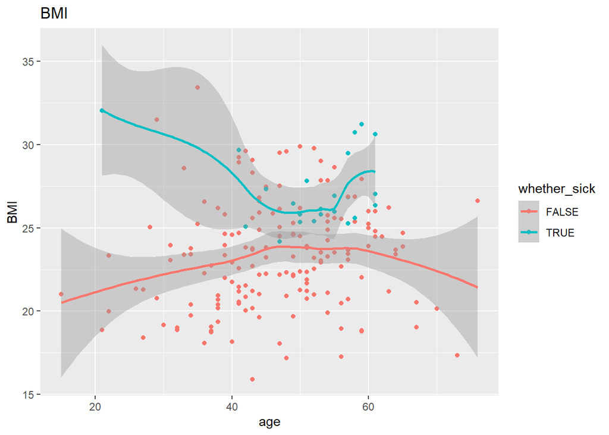

```r
ggplot(data = phy_test)+
  geom_point(aes(x=age,y=BMI,color=whether_sick))+
  geom_smooth(aes(x=age,y=BMI,color=whether_sick))+
  labs(title = "BMI")
```

```r
phy_test %>% group_by(whether_sick) %>%
  summarise(mean(FPG)) %>% ungroup()
```

```
## # A tibble: 2 x 2
##   whether_sick `mean(FPG)`
##   <lgl>              <dbl>
## 1 FALSE               5.36
## 2 TRUE                6.52
```

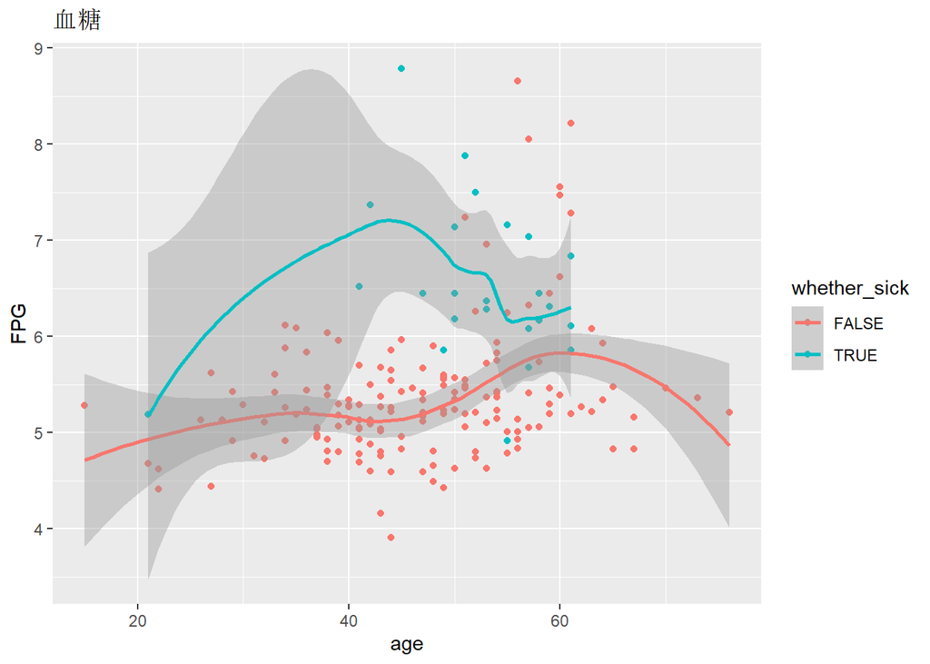

```r
ggplot(data = phy_test)+
  geom_point(aes(x=age,y=FPG,color=whether_sick))+
  geom_smooth(aes(x=age,y=FPG,color=whether_sick))+
  labs(title = "血糖")
```

```r
phy_test %>% group_by(whether_sick) %>%
  summarise(mean(sbp)) %>% ungroup()
```

```
## # A tibble: 2 x 2
##   whether_sick `mean(sbp)`
##   <lgl>              <dbl>
## 1 FALSE               116.
## 2 TRUE                132.
```

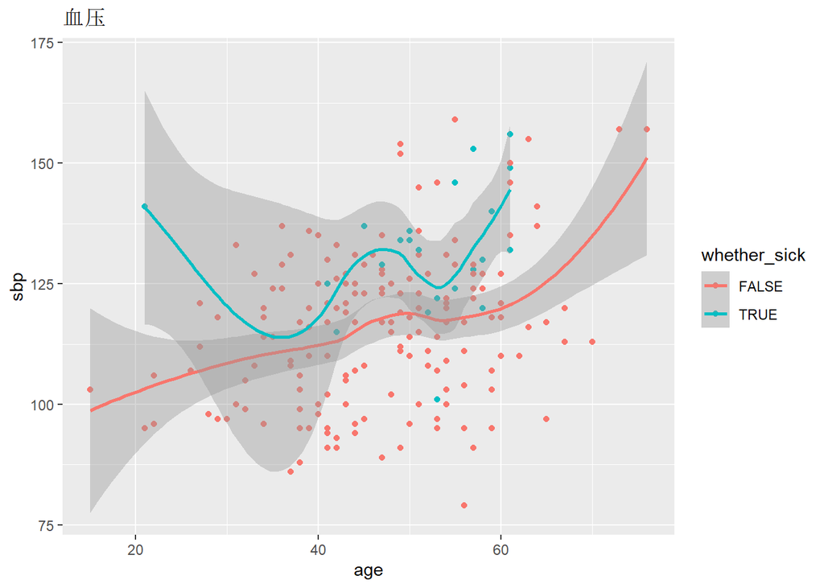

```r
ggplot(data = phy_test)+
  geom_point(aes(x=age,y=sbp,color=whether_sick))+
  geom_smooth(aes(x=age,y=sbp,color=whether_sick))+
  labs(title = "血压")
```

```r
phy_test %>% group_by(whether_sick) %>%
  summarise(mean(TG)) %>% ungroup()
```

```
## # A tibble: 2 x 2
##   whether_sick `mean(TG)`
##   <lgl>             <dbl>
## 1 FALSE              1.72
## 2 TRUE               2.93
```

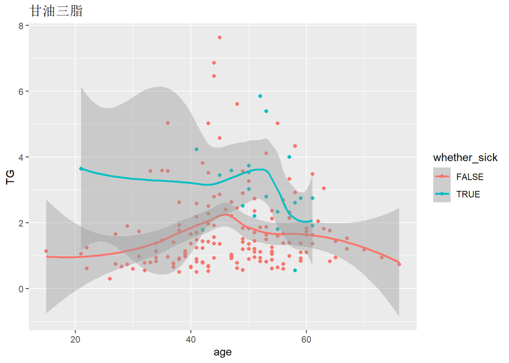

```r
ggplot(data = phy_test)+
  geom_point(aes(x=age,y=TG,color=whether_sick))+
  geom_smooth(aes(x=age,y=TG,color=whether_sick))+
  labs(title = "甘油三脂")
```

```r
phy_test %>% group_by(whether_sick) %>%
  summarise(mean(HDL_C)) %>% ungroup()
```

```
## # A tibble: 2 x 2
##   whether_sick `mean(HDL_C)`
##   <lgl>                <dbl>
## 1 FALSE                 1.62
## 2 TRUE                  1.45
```

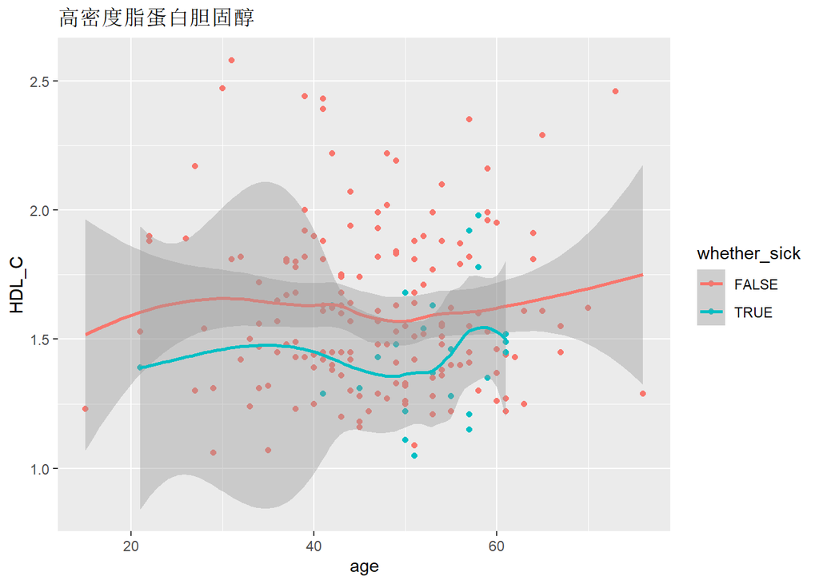

```r
ggplot(data = phy_test)+
  geom_point(aes(x=age,y=HDL_C,color=whether_sick))+
  geom_smooth(aes(x=age,y=HDL_C,color=whether_sick))+
  labs(title = "高密度脂蛋白胆固醇")
```

## 代谢综合症与不良生活习惯之间的关系

由下列的分析与数据可视化知，由抽烟习惯的人一般具有超重、高血糖、高血压、高甘油三酯与低高密度脂蛋白胆固醇这些特征，因此抽烟的人会有更大的概率换代谢综合症。

```r
phy_test %>% group_by(smoke) %>%
  summarise(mean(BMI)) %>% ungroup()
```

```
## # A tibble: 2 x 2
##   smoke `mean(BMI)`
##   <lgl>       <dbl>
## 1 FALSE        23.0
## 2 TRUE         25.5
```

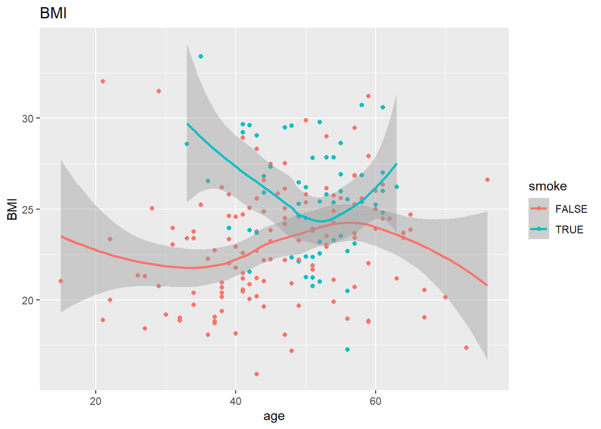

```r
ggplot(data = phy_test)+
  geom_point(aes(x=age,y=BMI,color=smoke))+
  geom_smooth(aes(x=age,y=BMI,color=smoke))+
  labs(title = "BMI")
```

```r
phy_test %>% group_by(smoke) %>%
  summarise(mean(FPG)) %>% ungroup()
```

```
## # A tibble: 2 x 2
##   smoke `mean(FPG)`
##   <lgl>       <dbl>
## 1 FALSE        5.40
## 2 TRUE         5.75
```

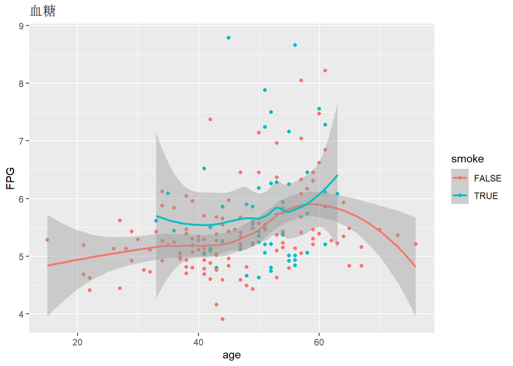

```r
ggplot(data = phy_test)+
  geom_point(aes(x=age,y=FPG,color=smoke))+
  geom_smooth(aes(x=age,y=FPG,color=smoke))+
  labs(title = "血糖")
```

```r
phy_test %>% group_by(smoke) %>%
  summarise(mean(sbp)) %>% ungroup()
```

```
## # A tibble: 2 x 2
##   smoke `mean(sbp)`
##   <lgl>       <dbl>
## 1 FALSE        116.
## 2 TRUE         122.
```

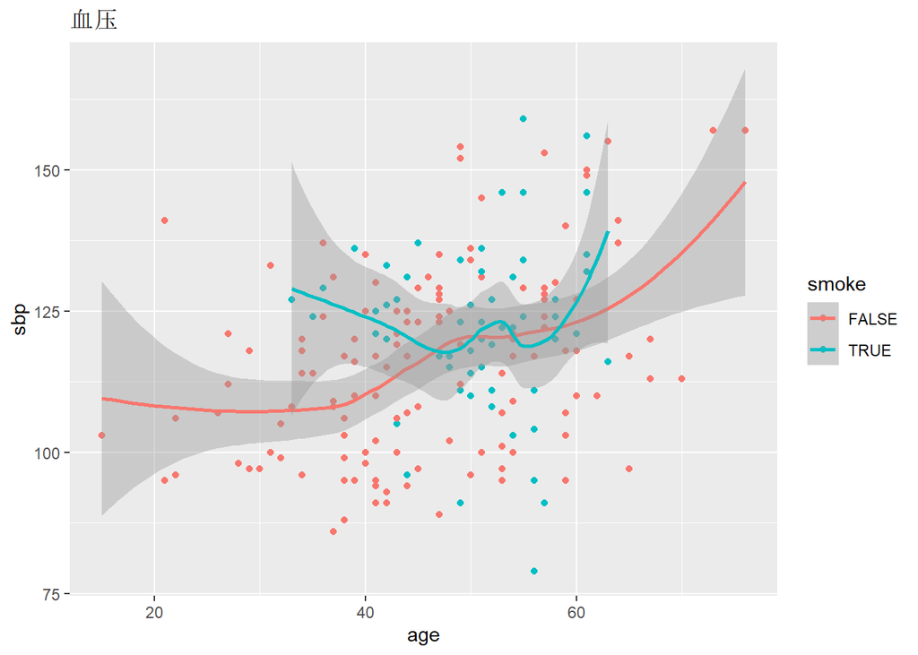

```r
ggplot(data = phy_test)+
  geom_point(aes(x=age,y=sbp,color=smoke))+
  geom_smooth(aes(x=age,y=sbp,color=smoke))+
  labs(title = "血压")
```

```r
phy_test %>% group_by(smoke) %>%
  summarise(mean(TG)) %>% ungroup()
```

```
## # A tibble: 2 x 2
##   smoke `mean(TG)`
##   <lgl>      <dbl>
## 1 FALSE       1.58
## 2 TRUE        2.52
```

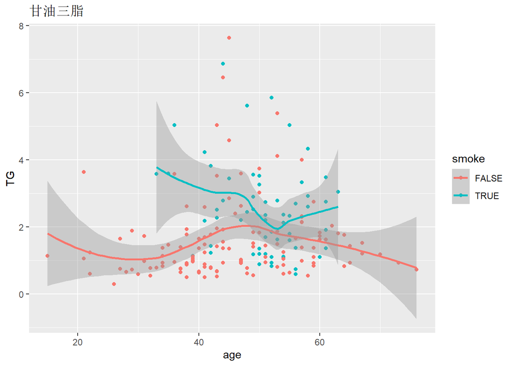

```r
ggplot(data = phy_test)+
  geom_point(aes(x=age,y=TG,color=smoke))+
  geom_smooth(aes(x=age,y=TG,color=smoke))+
  labs(title = "甘油三脂")
```

```r
phy_test %>% group_by(smoke) %>%
  summarise(mean(HDL_C)) %>% ungroup()
```

```
## # A tibble: 2 x 2
##   smoke `mean(HDL_C)`
##   <lgl>         <dbl>
## 1 FALSE          1.65
## 2 TRUE           1.48
```

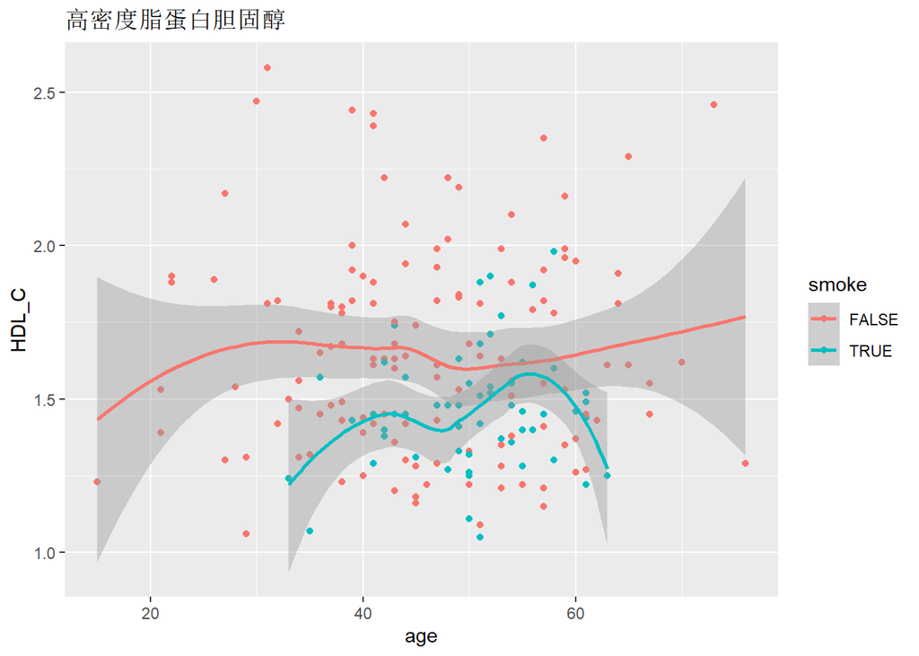

```r
ggplot(data = phy_test)+
  geom_point(aes(x=age,y=HDL_C,color=smoke))+
  geom_smooth(aes(x=age,y=HDL_C,color=smoke))+
  labs(title = "高密度脂蛋白胆固醇")
```

由下列的分析知，由饮酒习惯的人一般也都具有具有超重、高血糖、高血压、高甘油三酯与低高密度脂蛋白胆固醇这些特征，因此饮酒的人会得代谢综合症得概率更大一些

```r
phy_test %>% group_by(drunk) %>%
  summarise(mean(BMI)) %>% ungroup()
```

```
## # A tibble: 2 x 2
##   drunk `mean(BMI)`
##   <lgl>       <dbl>
## 1 FALSE        23.0
## 2 TRUE         25.0
```

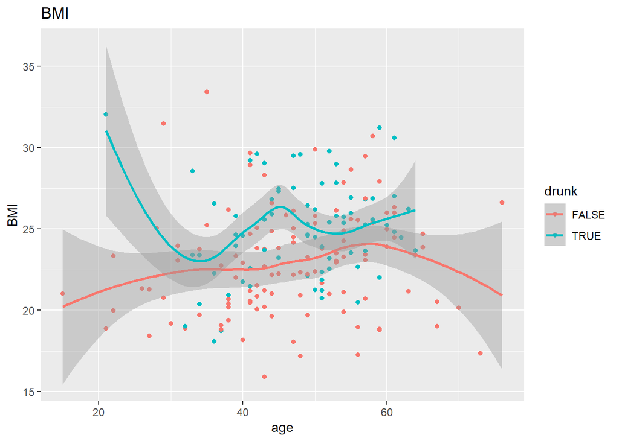

```r
ggplot(data = phy_test)+
  geom_point(aes(x=age,y=BMI,color=drunk))+
  geom_smooth(aes(x=age,y=BMI,color=drunk))+
  labs(title = "BMI")
```

```r
phy_test %>% group_by(drunk) %>%
  summarise(mean(FPG)) %>% ungroup()
```

```
## # A tibble: 2 x 2
##   drunk `mean(FPG)`
##   <lgl>       <dbl>
## 1 FALSE        5.41
## 2 TRUE         5.67
```

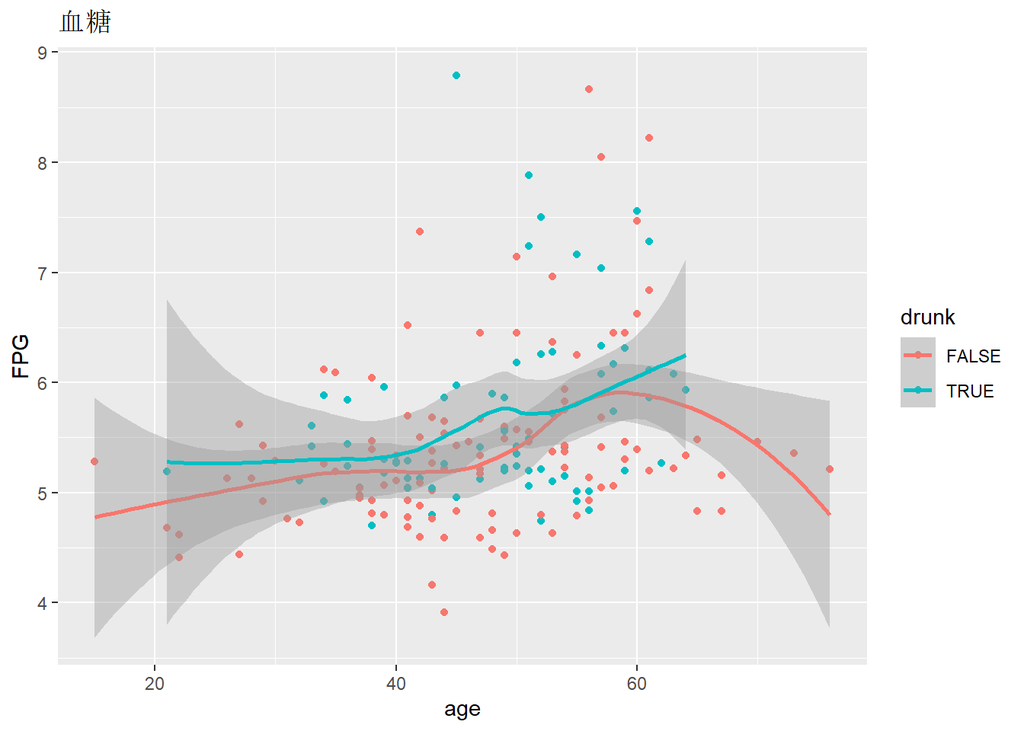

```r
ggplot(data = phy_test)+
  geom_point(aes(x=age,y=FPG,color=drunk))+
  geom_smooth(aes(x=age,y=FPG,color=drunk))+
  labs(title = "血糖")
```

```r
phy_test %>% group_by(drunk) %>%
  summarise(mean(sbp)) %>% ungroup()
```

```
## # A tibble: 2 x 2
##   drunk `mean(sbp)`
##   <lgl>       <dbl>
## 1 FALSE        116.
## 2 TRUE         121.
```

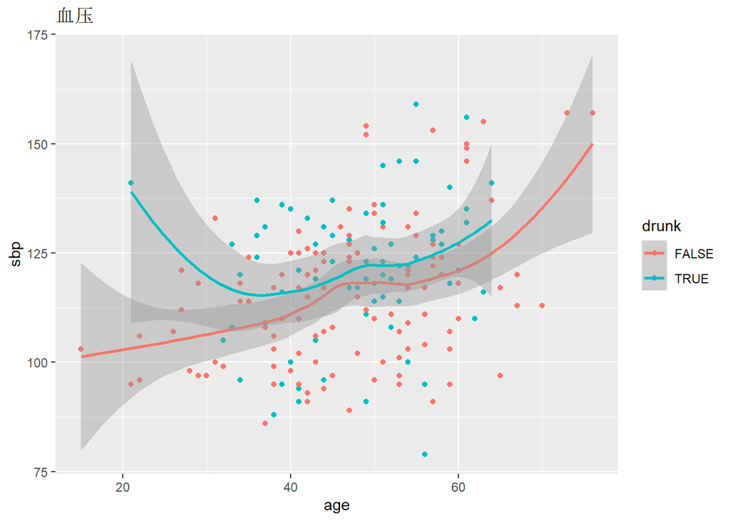

```r
ggplot(data = phy_test)+
  geom_point(aes(x=age,y=sbp,color=drunk))+
  geom_smooth(aes(x=age,y=sbp,color=drunk))+
  labs(title = "血压")
```

```r
phy_test %>% group_by(drunk) %>%
  summarise(mean(TG)) %>% ungroup()
```

```
## # A tibble: 2 x 2
##   drunk `mean(TG)`
##   <lgl>      <dbl>
## 1 FALSE       1.60
## 2 TRUE        2.29
```

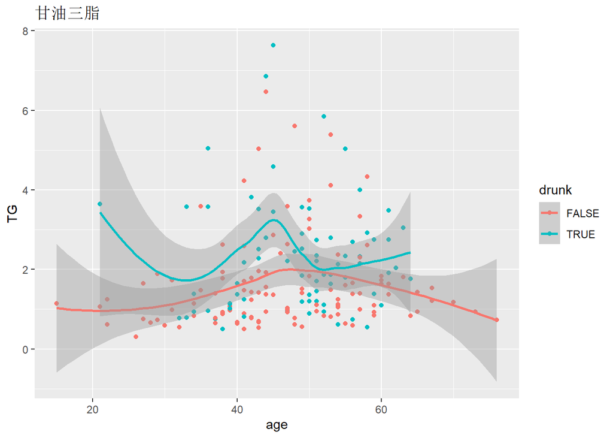

```r
ggplot(data = phy_test)+
  geom_point(aes(x=age,y=TG,color=drunk))+
  geom_smooth(aes(x=age,y=TG,color=drunk))+
  labs(title = "甘油三脂")
```

```r
phy_test %>% group_by(drunk) %>%
  summarise(mean(HDL_C)) %>% ungroup()
```

```
## # A tibble: 2 x 2
##   drunk `mean(HDL_C)`
##   <lgl>         <dbl>
## 1 FALSE          1.63
## 2 TRUE           1.55
```

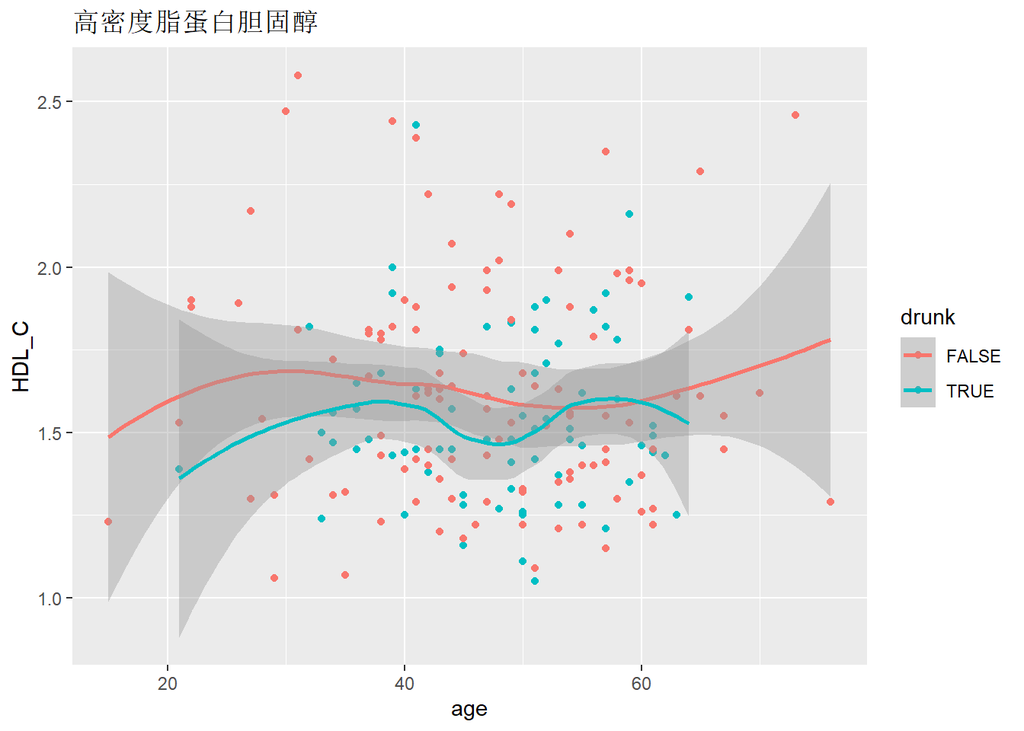

```r
ggplot(data = phy_test)+
  geom_point(aes(x=age,y=HDL_C,color=drunk))+
  geom_smooth(aes(x=age,y=HDL_C,color=drunk))+
  labs(title = "高密度脂蛋白胆固醇")
```

## 简单研究一下收缩压与舒张压之间的回归

发现线性回归的拟合效果就非常不错

```r
lm(data = phy_test,sbp~dbp)
```

```
##
## Call:
## lm(formula = sbp ~ dbp, data = phy_test)
##
## Coefficients:
## (Intercept)          dbp
##      27.603        1.192
```

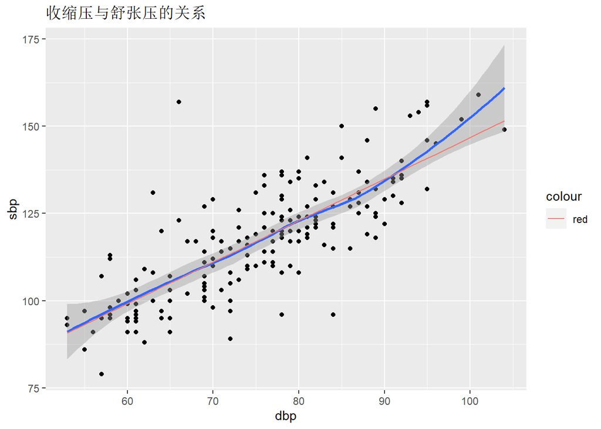

```r
ggplot(data = phy_test)+
  geom_point(aes(x=dbp,y=sbp))+
  geom_smooth(aes(x=dbp,y=sbp))+
  geom_line(aes(x=dbp,y=27.6+1.192*dbp,col='red'))+
  labs(title = "收缩压与舒张压的关系")
```